# Модель Эрдёша — Реньи G(n,p)

**Неориентированные** графы G  
**p - параметр:** определяет вероятность появления ребра между двумя вершинами:

### Плотность:

**Если 𝑝 = 1:** граф будет полным (максимально плотным).  
**Если 𝑝 = 0:** граф будет пустым (без рёбер, минимальная плотность).  
**Значения 𝑝 между 0 и 1:** чем больше 𝑝 - тем больше рёбер будет добавлено в граф -> плотность возрастёт.

## ✅ Подключение пакетов:

1. **NetworkX** — это библиотека, предназначенная для создания, анализа и визуализации сложных сетей и графов
2. **Matplotlib.pyplot** - научная графика

```python
import networkx as nx
import matplotlib.pyplot as plt
```

## ✅ Подсчет характеристик графа

```python
def calculate_Graph_characteristics(G):
    # Вычисление плотности графа
    density = nx.density(G)
    print(f"Плотность: {density}")

    # Связность
    is_connected = nx.is_connected(G)
    largest_component = max(nx.connected_components(G), key=len)
    print(f"Связность: {is_connected}")
    print(f"Размер наибольшей компоненты: {len(largest_component)}")

    # Диаметр
    diameter = nx.diameter(G)
    print(f"Диаметр: {diameter}")

    # Длина среднего кратчайшего пути
    average_shortest_path_length = nx.average_shortest_path_length(G)
    print(f"Средняя длина кратчайшего пути: {average_shortest_path_length}")

    # Средний коэффициент кластеризации
    average_clustering = nx.average_clustering(G)
    print(f"Средний коэффициент кластеризации: {average_clustering}")

    # Получаем степени всех узлов
    degree_sequence = [degree for node, degree in G.degree()]
    plt.hist(degree_sequence, bins=50)
    plt.title("Degree Distribution")
    plt.xlabel("Degree")
    plt.ylabel("Count")
    plt.show()
```

## ✅ Графы размера n = 10 с разной плотностью при p = 1; 0.9; 0.4

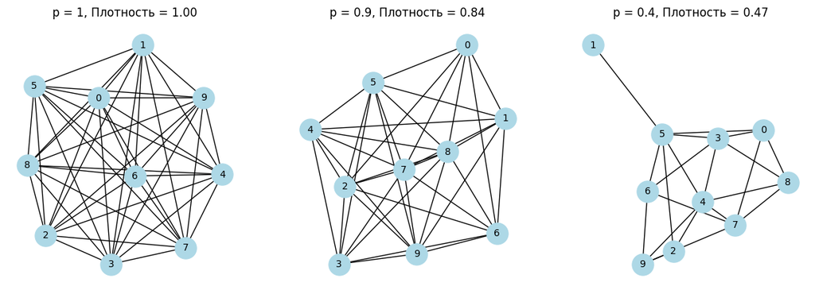

```python
# Параметры графов
n = 10
p_values = [1, 0.9, 0.4]

# Создание фигуры для рисования подграфиков
fig, axes = plt.subplots(1, len(p_values), figsize=(15, 5))  # один ряд, количество столбцов = количеству графов
G1, G2, G3 = [], [], []

for i, p in enumerate(p_values):
    # Генерация графа Эрдёша-Реньи
    G = nx.erdos_renyi_graph(n, p)
    if(i == 0): G1 = G
    if(i == 1): G2 = G
    if(i == 2): G3 = G

    # Вычисление плотности графа
    density = nx.density(G)

    # Отрисовка графа на соответствующей оси
    ax = axes[i]
    nx.draw(G, with_labels = True, node_color = "lightblue", node_size = 500, font_size = 10, ax = ax)

    # Установка заголовка с показом вероятности p и плотности
    ax.set_title(f"p = {p}, Плотность = {density:.2f}")

# Показываем все графы
plt.show()
```

```
Плотность: 1.0
Связность: True
Размер наибольшей компоненты: 10
Диаметр: 1
Средняя длина кратчайшего пути: 1.0
Средний коэффициент кластеризации: 1.0
```

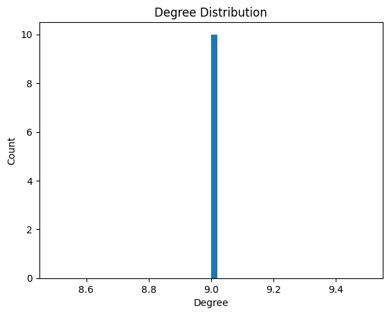

```python
calculate_Graph_characteristics(G1)
```

```
Плотность: 0.8444444444444444
Связность: True
Размер наибольшей компоненты: 10
Диаметр: 2
Средняя длина кратчайшего пути: 1.1555555555555554
Средний коэффициент кластеризации: 0.8406349206349206
```

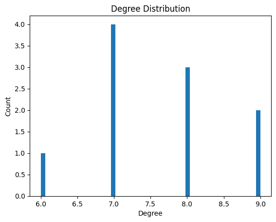

```python
calculate_Graph_characteristics(G2)
```

```
Плотность: 0.4666666666666667
Связность: True
Размер наибольшей компоненты: 10
Диаметр: 3
Средняя длина кратчайшего пути: 1.6
Средний коэффициент кластеризации: 0.42333333333333334
```

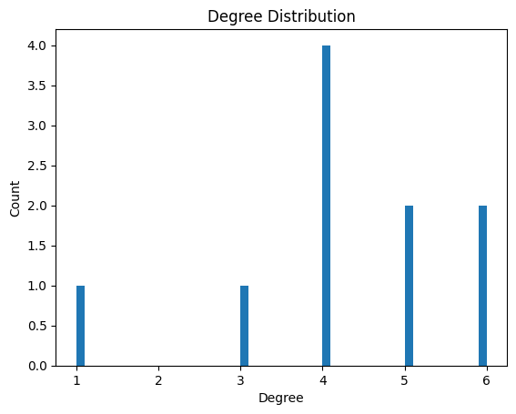

```python
calculate_Graph_characteristics(G3)
```

## ✅ Рассмотрим графы 4ех разных размерностей и 3ех видов плотности

### 💢 $G_{1}$: $n = 100000$ и $p = 0.000124$

```python
n = 100000  # количество вершин
p = 0.000124  # вероятность появления ребра

# Генерация графа Эрдёша-Реньи
G_1 = nx.erdos_renyi_graph(n, p)
```

```python
num_edges = G_1.number_of_edges()
print(num_edges)
```

```
621894
```

### 1️⃣ Плотность

Неориентированный граф  
**𝑛:** вершин  
**𝑚:** рёбер

$$ D = \frac{2m}{n(n-1)} $$

```python
# Вычисление плотности графа
density = nx.density(G_1)
print(f"Плотность: {density}")
```

```
Плотность: 0.000124380043800438
```

### 2️⃣ Связность

**Связный граф** - это граф, в котором существует путь между любой парой вершин.

```python
# Связность
is_connected = nx.is_connected(G_1)
largest_component = max(nx.connected_components(G_1), key=len)
print(f"Связность: {is_connected}")
print(f"Размер наибольшей компоненты: {len(largest_component)}")
```

```
Связность: True
Размер наибольшей компоненты: 100000
```

### 3️⃣ Диаметр

**Диаметр графа** — это наибольшая длина кратчайшего пути между двумя вершинами в графе.  
'#' Если граф несвязный, диаметр обычно считается бесконечным, потому что не существует пути между некоторыми вершинами.

```python
# Диаметр

if(is_connected):
    diameter = nx.diameter(G_1)
else:
    diameter = -1

print(f"Диаметр: {diameter}")
```

```
Диаметр: 8
```

### 4️⃣ Длина среднего кратчайшего пути

**Длина среднего кратчайшего пути** — это среднее значение всех кратчайших путей между всеми парами вершин в графе
$$\frac{1}{n(n-1)} \sum_{u, v \in V, u \neq v} d(u, v)$$
**d(u,v):** длина кратчайшего пути между u и v

```python
# Длина среднего кратчайшего пути
average_shortest_path_length = nx.average_shortest_path_length(G_1)
print(f"Средняя длина кратчайшего пути: {average_shortest_path_length}")
```

```
Средняя длина кратчайшего пути: 4.83186125501255
```

### 5️⃣ Средний коэффициент кластеризации

**Средний коэффициент кластеризации (Average Clustering Coefficient)** - это среднее значение коэффициентов кластеризации всех вершин графа:
**Коэффициент кластеризации** измеряет, насколько вероятно, что два соседа одной вершины также соединены между собой (образуют треугольник).
$$G_{avg} = \frac{1}{n}\sum_{v \in V} G_{v}$$
**'#'** насколько вершины склонны образовывать группы (или «кластеры»).

```python
# Средний коэффициент кластеризации
average_clustering = nx.average_clustering(G_1)
print(f"Средний коэффициент кластеризации: {average_clustering}")
```

```
Средний коэффициент кластеризации: 0.00013049317201023353
```

### 6️⃣ Распределение степеней

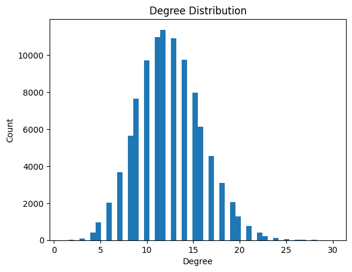

```python
# Получаем степени всех узлов
degree_sequence = [degree for node, degree in G_1.degree()]
plt.hist(degree_sequence, bins = 50)
plt.title("Degree Distribution")
plt.xlabel("Degree")
plt.ylabel("Count")
plt.show()
```

### 💢 $G_{2}$: $n = 100000$ и $p = 0.0005$

```python
n = 100000  # количество вершин
p = 0.0005  # вероятность появления ребра

# Генерация графа Эрдёша-Реньи
G_2 = nx.erdos_renyi_graph(n, p)
```

```python
num_edges = G_2.number_of_edges()
print(num_edges)
```

```
2499430
```

```python
# Вычисление плотности графа
density = nx.density(G_2)
print(f"Плотность: {density}")
```

```
Плотность: 0.0004998909989099891
```

```python
# Связность
is_connected = nx.is_connected(G_2)
largest_component = max(nx.connected_components(G_2), key=len)
print(f"Связность: {is_connected}")
print(f"Размер наибольшей компоненты: {len(largest_component)}")
```

```
Связность: True
Размер наибольшей компоненты: 100000
```

```python
diameter = nx.diameter(G_2)
print(f"Диаметр: {diameter}")
```

```
Диаметр: 4
```

```python
# Длина среднего кратчайшего пути
average_shortest_path_length = nx.average_shortest_path_length(G_2)
print(f"Средняя длина кратчайшего пути: {average_shortest_path_length}")
```

```
Средняя длина кратчайшего пути: 3.2628153479534796
```

### 💢 $G_{3}$: $n = 110000$ и $p = 0.00011$

```python
n = 110000  # количество вершин
p = 0.00011  # вероятность появления ребра

# Генерация графа Эрдёша-Реньи
G_3 = nx.erdos_renyi_graph(n, p)
```

```python
num_edges = G_3.number_of_edges()
print(num_edges)
```

```
664086
```

```python
# Вычисление плотности графа
density = nx.density(G_3)
print(f"Плотность: {density}")
```

```
Плотность: 0.00010976727887608895
```

```python
# Связность
is_connected = nx.is_connected(G_3)
largest_component = max(nx.connected_components(G_3), key=len)
print(f"Связность: {is_connected}")
print(f"Размер наибольшей компоненты: {len(largest_component)}")
```

```
Связность: True
Размер наибольшей компоненты: 110000
```

```python
# Диаметр

diameter = nx.diameter(G_3)
print(f"Диаметр: {diameter}")
```

```
Диаметр: 8
```

```python
# Длина среднего кратчайшего пути
average_shortest_path_length = nx.average_shortest_path_length(G_3)
print(f"Средняя длина кратчайшего пути: {average_shortest_path_length}")
```

```
Средняя длина кратчайшего пути: 4.919782730752098
```

```python
# Средний коэффициент кластеризации
average_clustering = nx.average_clustering(G_3)
print(f"Средний коэффициент кластеризации: {average_clustering}")
```

```
Средний коэффициент кластеризации: 0.00010510399312513877
```

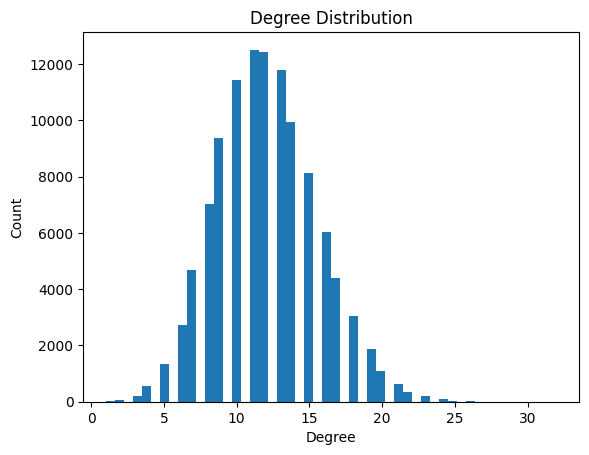

```python
# Получаем степени всех узлов
degree_sequence = [degree for node, degree in G_3.degree()]
plt.hist(degree_sequence, bins = 50)
plt.title("Degree Distribution")
plt.xlabel("Degree")
plt.ylabel("Count")
plt.show()
```

### 💢 $G_{4}$: $n = 130000$ и $p = 0.00008$

```python
n = 130000  # количество вершин
p = 0.00008  # вероятность появления ребра

# Генерация графа Эрдёша-Реньи
G_4 = nx.erdos_renyi_graph(n, p)
```

```python
num_edges = G_4.number_of_edges()
print(num_edges)
```

```
675884
```

```python
# Вычисление плотности графа
density = nx.density(G_4)
print(f"Плотность: {density}")
```

```
Плотность: 7.99868874730989e-05
```

```python
# Связность
is_connected = nx.is_connected(G_4)
largest_component = max(nx.connected_components(G_4), key=len)
print(f"Связность: {is_connected}")
print(f"Размер наибольшей компоненты: {len(largest_component)}")
```

```
Связность: True
Размер наибольшей компоненты: 130000
```

```python
diameter = nx.diameter(G_4)
print(f"Диаметр: {diameter}")
```

```
Диаметр: 9
```

```python
# Длина среднего кратчайшего пути
average_shortest_path_length = nx.average_shortest_path_length(G_4)
print(f"Средняя длина кратчайшего пути: {average_shortest_path_length}")
```

```
Средняя длина кратчайшего пути: 5.293988449496949
```

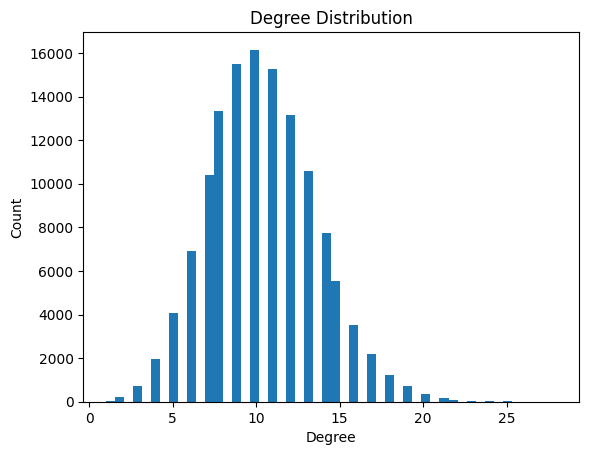

```python
# Получаем степени всех узлов
degree_sequence = [degree for node, degree in G_4.degree()]
plt.hist(degree_sequence, bins = 50)
plt.title("Degree Distribution")
plt.xlabel("Degree")
plt.ylabel("Count")
plt.show()
```

### 💢 Несвязный граф $G_{5}$: $n = 140000$ и $p = 0.00001$

```python
n = 140000  # количество вершин
p = 0.00001  # вероятность появления ребра

# Генерация графа Эрдёша-Реньи
G_5 = nx.erdos_renyi_graph(n, p)
```

```python
num_edges = G_5.number_of_edges()
print(num_edges)
```

```
97910
```

```python
# Вычисление плотности графа
density = nx.density(G_5)
print(f"Плотность: {density}")
```

```
Плотность: 9.990887690014112e-06
```

```python
# Связность
is_connected = nx.is_connected(G_5)
largest_component = max(nx.connected_components(G_5), key=len)
print(f"Связность: {is_connected}")
print(f"Размер наибольшей компоненты: {len(largest_component)}")
```

```
Связность: False
Размер наибольшей компоненты: 71557
```

```python
# Получаем список связных компонент
connected_components = list(nx.connected_components(G_5))

# Выбираем наибольшую компоненту
largest_component = max(connected_components, key=len)

# Создаем подграф для наибольшей компоненты
lcc = G_5.subgraph(largest_component)
```

```python
# Количество вершин в подграфе

num_nodes = lcc.number_of_nodes()
print(f"Количество вершин подграфа: {num_nodes}") # Вывод: Количество вершин: 7
```

```
Количество вершин подграфа: 71557
```

```python
# Количество ребер в подграфе

num_edges = lcc.number_of_edges()
print(f"Количество ребер в подграфе: {num_edges}")
```

```
Количество ребер в подграфе: 74472
```

```python
# Вычисление плотности графа

density = nx.density(lcc)
print(f"Плотность подграфа: {density}")
```

```
Плотность подграфа: 2.9088734845825523e-05
```

```python
# Диаметр

diameter = nx.diameter(lcc)
print(f"Диаметр подграфа: {diameter}")
```

```
Диаметр подграфа: 77
```

```python
# Длина среднего кратчайшего пути
average_shortest_path_length = nx.average_shortest_path_length(lcc)
print(f"Средняя длина кратчайшего пути в подграфе: {average_shortest_path_length}")
```

```
Средняя длина кратчайшего пути в подграфе: 29.452332794628493
```

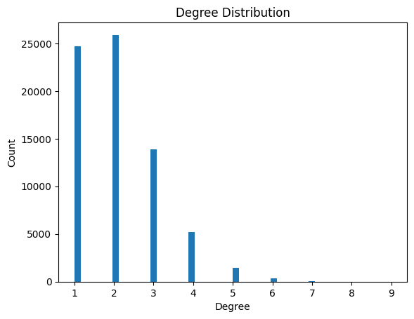

```python
# Получаем степени всех узлов
degree_sequence = [degree for node, degree in lcc.degree()]
plt.hist(degree_sequence, bins = 50)
plt.title("Degree Distribution")
plt.xlabel("Degree")
plt.ylabel("Count")
plt.show()
```

# Выводы

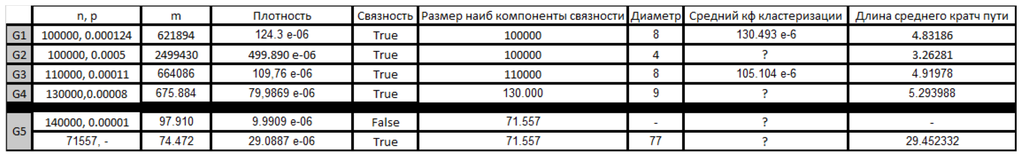

```python
import matplotlib.image as mpimg

img1 = mpimg.imread('F:/table.png')
# Создание графика
fig, ax = plt.subplots(1, 1, figsize=(25, 25))

# Отображение первого изображения
ax.imshow(img1)
ax.axis('off')  # Скрыть оси

plt.show()
```

### $G_{1}$ и $G_{2}$: увеличили вероятность добавления ребра:

**1.** увлеичилась плотность  
**2.** граф остался связным  
**3.** уменьшился диаметр, т.к. больше ребер  
**4.** с уменьшением диаметра уменьшилась и длина среднего кратчайшего пути

**1.** количество ребер примерно одинаковое, т.к. вероятность доавбления ребра с увеличением количества вершин - уменьшалась  
**2.** плотность у графов уменьшается, т.к. число вершин увеличвается, а количество ребер - примерно одинаковое **3.** все четыре графа получились связными  
**4.** диаметр примерно такой же, но при n = 130000 диаметр вырос на 1, т.к. плотность уменьшилась по сравнению с $G_{1}, G_{3}$  
**5.** длина среднего кратчайшего пути возрастает